# 다변량자료분석 HW7

‘수학과 201521139 이재학’

2021-05-12

##### **데이터 불러오기**

```r
x<-read.table('C:/Users/이재학/Desktop/PlaceRating.txt')
x<-x[,1:9]                    #9개의 변수만 사용
head(x)
```

```
##                            Climate HousingCost HlthCare Crime Transp Educ Arts
## Abilene,TX                     521        6200      237   923   4031 2757  996
## Akron,OH                       575        8138     1656   886   4883 2438 5564
## Albany,GA                      468        7339      618   970   2531 2560  237
## Albany-Schenectady-Troy,NY     476        7908     1431   610   6883 3399 4655
## Albuquerque,NM                 659        8393     1853  1483   6558 3026 4496
## Alexandria,LA                  520        5819      640   727   2444 2972  334
##                            Recreat Econ
## Abilene,TX                    1405 7633
## Akron,OH                      2632 4350
## Albany,GA                      859 5250
## Albany-Schenectady-Troy,NY    1617 5864
## Albuquerque,NM                2612 5727
## Alexandria,LA                 1018 5254
```

##### **데이터 전처리**

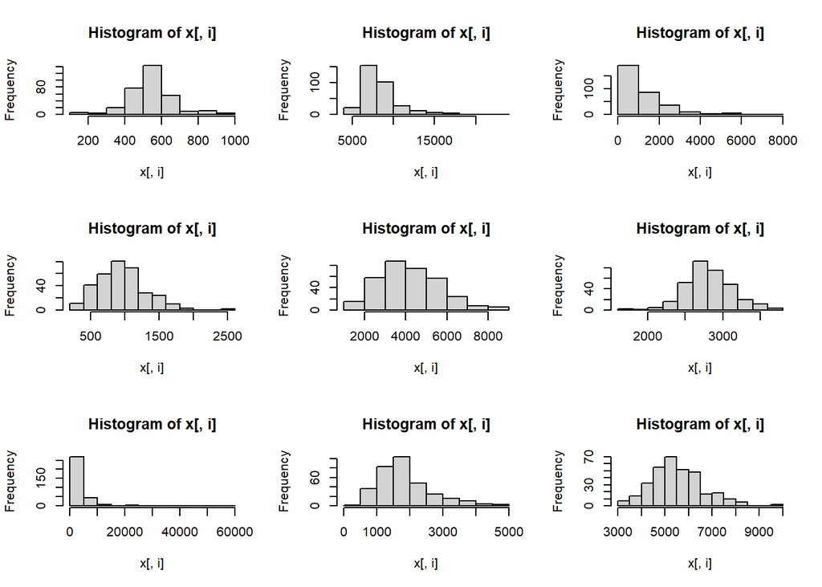

```r
par(mfrow=c(3,3))
for (i in 1:9){
  hist(x[,i])
}
```

##### **Right skewed -> log transformation**

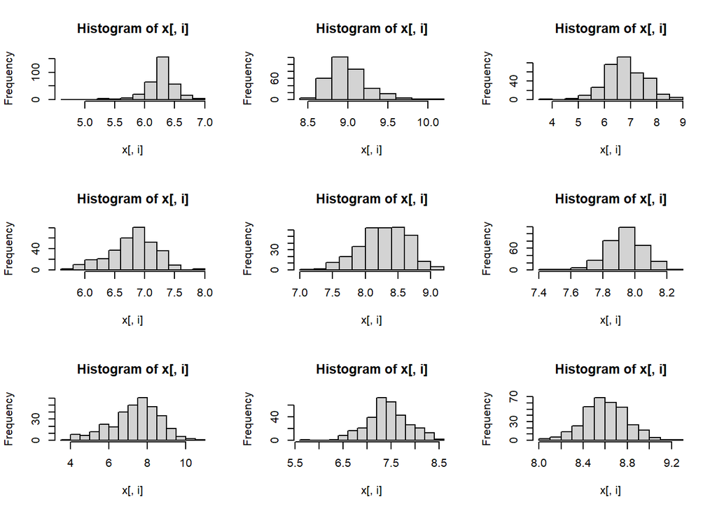

```r
x<-log(x)
par(mfrow=c(3,3))
for (i in 1:9){
  hist(x[,i])
}
```

##### **log transformation 한 이후에 어느정도의 정규분포를 띄는 모습을 확인 할 수 있다.**

##### **Apply PCA to this PlaceRating data after standardizing the variables**

```r
x<-scale(x)                  #표준화
P=cov(x)                     #표준화한 변수의 공분산행렬 ->Cov(Z)=Cor(X)=P
eigen(P)
```

```
## eigen() decomposition
## $values
## [1] 3.2977930 1.2135619 1.1055299 0.9072798 0.8606287 0.5621858 0.4838206
## [8] 0.3180722 0.2511282
##
## $vectors
##             [,1]        [,2]        [,3]        [,4]        [,5]          [,6]
##  [1,] -0.1579414 -0.06862938  0.79970997  0.37680952 -0.04104588 -0.2166949681
##  [2,] -0.3844053 -0.13920883  0.07961647  0.19654301  0.57986793  0.0822200812
##  [3,] -0.4099096  0.37181203 -0.01947537  0.11252206 -0.02956935  0.5348756017
##  [4,] -0.2591017 -0.47413246  0.12846722 -0.04229962 -0.69217100  0.1399009169
##  [5,] -0.3748890  0.14148642 -0.14106828 -0.43007675 -0.19141608 -0.3238913974
##  [6,] -0.2743254  0.45235526 -0.24105584  0.45694297 -0.22474374 -0.5265827320
##  [7,] -0.4738471  0.10441020  0.01102628 -0.14688130 -0.01193024  0.3210570706
##  [8,] -0.3534118 -0.29194243  0.04181639 -0.40401889  0.30565371 -0.3941387718
##  [9,] -0.1640135 -0.54045312 -0.50731026  0.47578009  0.03710776  0.0009737383
##             [,7]       [,8]        [,9]
##  [1,]  0.1513516 -0.3411282  0.03009755
##  [2,]  0.2751971  0.6061010 -0.04226906
##  [3,] -0.1349750 -0.1500575  0.59412763
##  [4,] -0.1095036  0.4201255  0.05101188
##  [5,]  0.6785670 -0.1188325  0.13584327
##  [6,] -0.2620958  0.2111749 -0.11012420
##  [7,] -0.1204986 -0.2598673 -0.74672678
##  [8,] -0.5530938 -0.1377181  0.22636544
##  [9,]  0.1468669 -0.4147736  0.04790278
```

```r
sum(eigen(P)$values)
```

```
## [1] 9
```

```r
mean(eigen(P)$values)        #m(<p)값 선택을 위한 기준
```

```
## [1] 1
```

###### **eigen 함수를 통해 상관행렬의 고유값과 고유벡터를 구할 수 있고, 고유값의 합이 p=9인 사실을 확인 할 수 있다.**

##### **PCA**

```r
place_pca=prcomp(x=x)
summary(place_pca)
```

```
## Importance of components:
##                           PC1    PC2    PC3    PC4     PC5     PC6     PC7
## Standard deviation     1.8160 1.1016 1.0514 0.9525 0.92770 0.74979 0.69557
## Proportion of Variance 0.3664 0.1348 0.1228 0.1008 0.09563 0.06247 0.05376
## Cumulative Proportion  0.3664 0.5013 0.6241 0.7249 0.82053 0.88300 0.93676
##                            PC8    PC9
## Standard deviation     0.56398 0.5011
## Proportion of Variance 0.03534 0.0279
## Cumulative Proportion  0.97210 1.0000
```

```r
print(place_pca)
```

```
## Standard deviations (1, .., p=9):
## [1] 1.8159827 1.1016178 1.0514418 0.9525124 0.9277008 0.7497905 0.6955721
## [8] 0.5639789 0.5011269
##
## Rotation (n x k) = (9 x 9):
##                   PC1         PC2         PC3         PC4         PC5
## Climate     0.1579414  0.06862938 -0.79970997  0.37680952 -0.04104588
## HousingCost 0.3844053  0.13920883 -0.07961647  0.19654301  0.57986793
## HlthCare    0.4099096 -0.37181203  0.01947537  0.11252206 -0.02956935
## Crime       0.2591017  0.47413246 -0.12846722 -0.04229962 -0.69217100
## Transp      0.3748890 -0.14148642  0.14106828 -0.43007675 -0.19141608
## Educ        0.2743254 -0.45235526  0.24105584  0.45694297 -0.22474374
## Arts        0.4738471 -0.10441020 -0.01102628 -0.14688130 -0.01193024
## Recreat     0.3534118  0.29194243 -0.04181639 -0.40401889  0.30565371
## Econ        0.1640135  0.54045312  0.50731026  0.47578009  0.03710776
##                       PC6        PC7        PC8         PC9
## Climate      0.2166949681 -0.1513516 -0.3411282 -0.03009755
## HousingCost -0.0822200812 -0.2751971  0.6061010  0.04226906
## HlthCare    -0.5348756017  0.1349750 -0.1500575 -0.59412763
## Crime       -0.1399009169  0.1095036  0.4201255 -0.05101188
## Transp       0.3238913974 -0.6785670 -0.1188325 -0.13584327
## Educ         0.5265827320  0.2620958  0.2111749  0.11012420
## Arts        -0.3210570706  0.1204986 -0.2598673  0.74672678
## Recreat      0.3941387718  0.5530938 -0.1377181 -0.22636544
## Econ        -0.0009737383 -0.1468669 -0.4147736 -0.04790278
```

##### **m(<p)의 값을 찾기 위한 시각화**

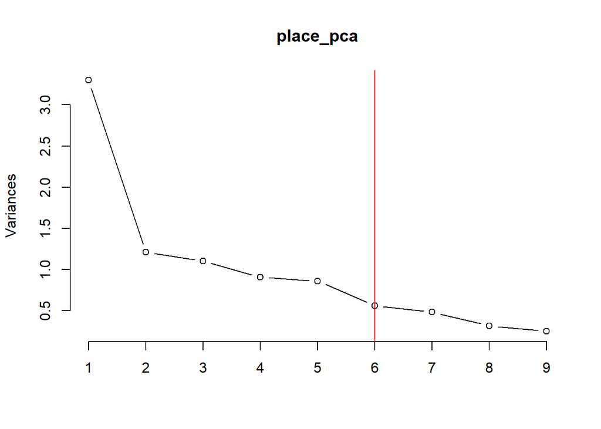

```r
screeplot(place_pca,npcs=9,type="lines")
abline(v=6,col='red')
```

#### 수업시간에 배운 기준을 적용하면, 1.80~90% : PC6 2.mean : PC3 3.Scree Plot : PC6 (maybe elbow?)

##### **PC score and correlation with data**

```r
PCscore=as.matrix(x)%*%(place_pca$rotation)
cor(x,PCscore)
```

```
##                   PC1         PC2         PC3         PC4         PC5
## Climate     0.2868188  0.07560335 -0.84084849  0.35891574 -0.03807829
## HousingCost 0.6980733  0.15335494 -0.08371209  0.18720965  0.53794392
## HlthCare    0.7443888 -0.40959477  0.02047721  0.10717865 -0.02743151
## Crime       0.4705242  0.52231278 -0.13507581 -0.04029091 -0.64212756
## Transp      0.6807920 -0.15586396  0.14832509 -0.40965343 -0.17757684
## Educ        0.4981701 -0.49832263  0.25345619  0.43524384 -0.20849493
## Arts        0.8604980 -0.11502014 -0.01159349 -0.13990625 -0.01106769
## Recreat     0.6417896  0.32160899 -0.04396750 -0.38483299  0.28355518
## Econ        0.2978456  0.59537280  0.53340722  0.45318643  0.03442489
##                       PC6         PC7         PC8         PC9
## Climate      0.1624758292 -0.10527596 -0.19238909 -0.01508269
## HousingCost -0.0616478361 -0.19141944  0.34182816  0.02118216
## HlthCare    -0.4010446465  0.09388486 -0.08462927 -0.29773333
## Crime       -0.1048963789  0.07616763  0.23694189 -0.02556343
## Transp       0.2428506938 -0.47199234 -0.06701904 -0.06807471
## Educ         0.3948267316  0.18230655  0.11909817  0.05518620
## Arts        -0.2407255425  0.08381544 -0.14655966  0.37420487
## Recreat      0.2955215081  0.38471662 -0.07767012 -0.11343781
## Econ        -0.0007300998 -0.10215653 -0.23392353 -0.02400537
```

###### **PCscore는 원래 데이터에 eigen vector를 곱한 값이다. 이는 새로운 공간에서 좌표값으로 나타난다-by google**

```r
k=i
i=1
place_pca$rotation[k,i]*sqrt(eigen(P)$values[i])
```

```
## [1] 0.2978456
```

##### **PCscore1 & PCscore2 시각화**

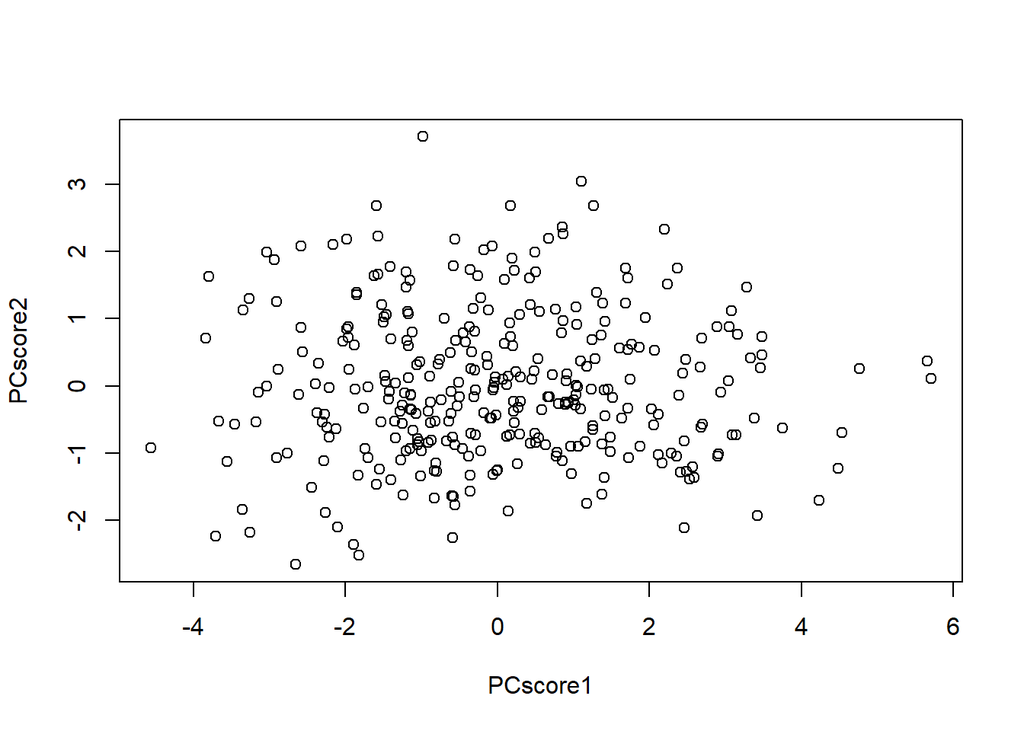

```r
PCscore1=as.matrix(x)%*%(place_pca$rotation[,1])
PCscore2=as.matrix(x)%*%(place_pca$rotation[,2])
plot(PCscore1,PCscore2)
```

##### **biplot**

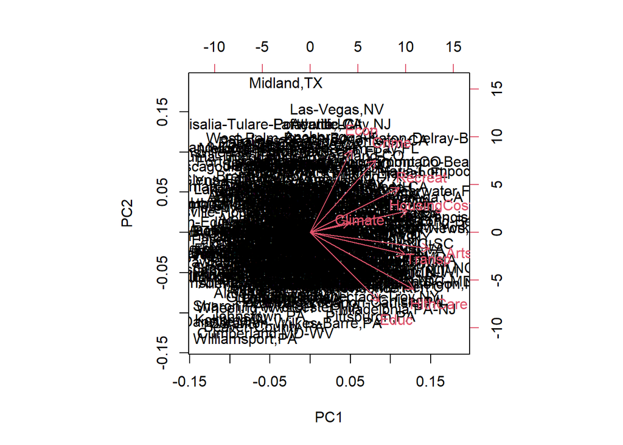

```r
biplot(place_pca)
```

### *National_Track_Men_Records Data*

##### **데이터 불러오기**

```r
y<-read.table('C:/Users/이재학/Desktop/National_Track_Men_Records.txt',header=T)
head(y)
```

```
##   X100m X200m X400m X800m X1500m X5000m X10000m Marathon   country
## 1 10.39 20.81 46.84  1.81   3.70  14.04   29.36   137.72  argentin
## 2 10.31 20.06 44.84  1.74   3.57  13.28   27.66   128.30 australia
## 3 10.44 20.81 46.82  1.79   3.60  13.26   27.72   135.90   austria
## 4 10.34 20.68 45.04  1.73   3.60  13.22   27.45   129.95   belgium
## 5 10.28 20.58 45.91  1.80   3.75  14.68   30.55   146.62   bermuda
## 6 10.22 20.43 45.21  1.73   3.66  13.62   28.62   133.13    brazil
```

```r
y<-y[,-9]                       #country 제외
py<-cor(y)
```

##### **(a) Obtaion the sample correlation matrix and determine its eigenvalues and eigenvectors**

```r
py
```

```
##              X100m     X200m     X400m     X800m    X1500m    X5000m   X10000m
## X100m    1.0000000 0.9226384 0.8411468 0.7560278 0.7002382 0.6194618 0.6325389
## X200m    0.9226384 1.0000000 0.8507270 0.8066265 0.7749513 0.6953770 0.6965391
## X400m    0.8411468 0.8507270 1.0000000 0.8701714 0.8352694 0.7786139 0.7872045
## X800m    0.7560278 0.8066265 0.8701714 1.0000000 0.9180442 0.8635939 0.8690489
## X1500m   0.7002382 0.7749513 0.8352694 0.9180442 1.0000000 0.9281140 0.9346970
## X5000m   0.6194618 0.6953770 0.7786139 0.8635939 0.9281140 1.0000000 0.9746354
## X10000m  0.6325389 0.6965391 0.7872045 0.8690489 0.9346970 0.9746354 1.0000000
## Marathon 0.5199490 0.5961837 0.7049905 0.8064764 0.8655492 0.9321884 0.9431763
##           Marathon
## X100m    0.5199490
## X200m    0.5961837
## X400m    0.7049905
## X800m    0.8064764
## X1500m   0.8655492
## X5000m   0.9321884
## X10000m  0.9431763
## Marathon 1.0000000
```

###### **correlation matrix**

```r
eigen(py)
```

```
## eigen() decomposition
## $values
## [1] 6.62214613 0.87761829 0.15932114 0.12404939 0.07988027 0.06796515 0.04641953
## [8] 0.02260010
##
## $vectors
##            [,1]        [,2]       [,3]        [,4]       [,5]       [,6]
## [1,] -0.3175565 -0.56687750  0.3322620 -0.12762827  0.2625555  0.5937042
## [2,] -0.3369792 -0.46162589  0.3606567  0.25911576 -0.1539571 -0.6561367
## [3,] -0.3556454 -0.24827331 -0.5604674 -0.65234077 -0.2183229 -0.1566252
## [4,] -0.3686841 -0.01242993 -0.5324823  0.47999895  0.5400528  0.0146918
## [5,] -0.3728099  0.13979665 -0.1534427  0.40451039 -0.4877151  0.1578430
## [6,] -0.3643741  0.31203045  0.1897643 -0.02958755 -0.2539792  0.1412987
## [7,] -0.3667726  0.30685985  0.1817517 -0.08006862 -0.1331764  0.2190168
## [8,] -0.3419261  0.43896267  0.2632087 -0.29951213  0.4979283 -0.3152849
##              [,7]          [,8]
## [1,]  0.136241260 -0.1055416752
## [2,] -0.112639528  0.0960543222
## [3,] -0.002853707  0.0001272032
## [4,] -0.238016094  0.0381651151
## [5,]  0.610011482 -0.1392909844
## [6,] -0.591298850 -0.5466969221
## [7,] -0.176871021  0.7967952190
## [8,]  0.398822209 -0.1581638575
```

###### **eigenvalues and eigenvectors**

##### **(b) Determine the fist two PCs**

```r
y<-scale(y)                   #표준화
pca_y=prcomp(x=y)
```

##### **m(<8)의 값을 찾기 위한 시각화**

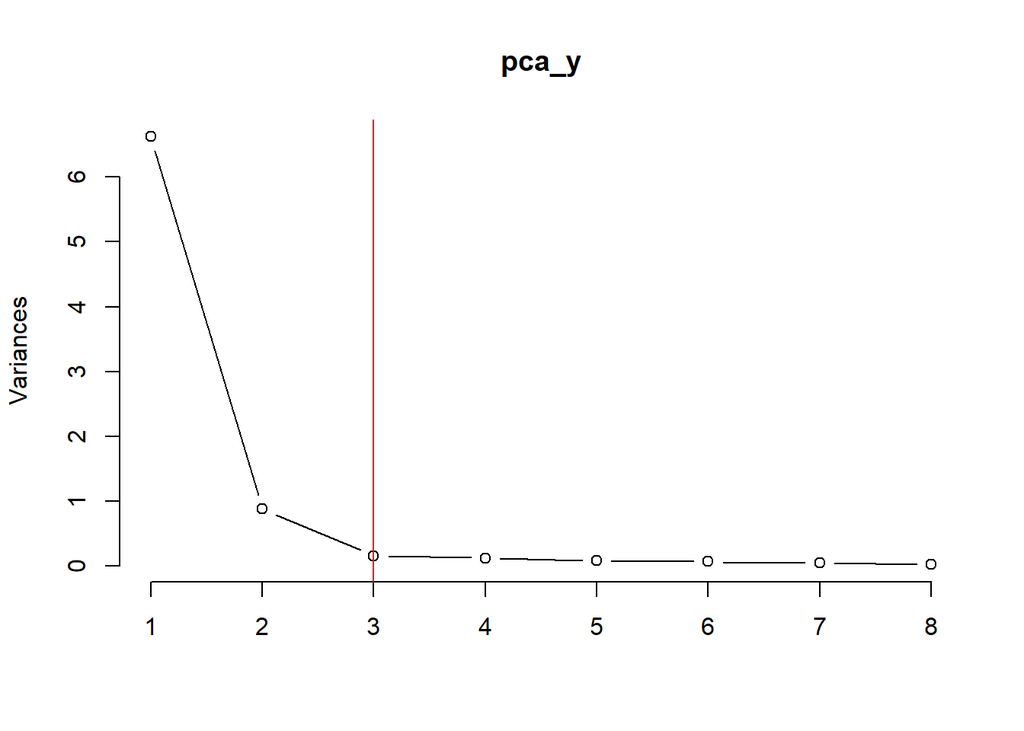

```r
screeplot(pca_y,npcs=8,type="lines")
abline(v=3,col='red')
```

##### **table showing the correlations of the standardized variables.**

```r
cor(y)
```

```
##              X100m     X200m     X400m     X800m    X1500m    X5000m   X10000m
## X100m    1.0000000 0.9226384 0.8411468 0.7560278 0.7002382 0.6194618 0.6325389
## X200m    0.9226384 1.0000000 0.8507270 0.8066265 0.7749513 0.6953770 0.6965391
## X400m    0.8411468 0.8507270 1.0000000 0.8701714 0.8352694 0.7786139 0.7872045
## X800m    0.7560278 0.8066265 0.8701714 1.0000000 0.9180442 0.8635939 0.8690489
## X1500m   0.7002382 0.7749513 0.8352694 0.9180442 1.0000000 0.9281140 0.9346970
## X5000m   0.6194618 0.6953770 0.7786139 0.8635939 0.9281140 1.0000000 0.9746354
## X10000m  0.6325389 0.6965391 0.7872045 0.8690489 0.9346970 0.9746354 1.0000000
## Marathon 0.5199490 0.5961837 0.7049905 0.8064764 0.8655492 0.9321884 0.9431763
##           Marathon
## X100m    0.5199490
## X200m    0.5961837
## X400m    0.7049905
## X800m    0.8064764
## X1500m   0.8655492
## X5000m   0.9321884
## X10000m  0.9431763
## Marathon 1.0000000
```

##### **cumulative percentage of the total(standardized) sample variance explained by the two components.**

```r
summary(pca_y)
```

```
## Importance of components:
##                           PC1    PC2     PC3     PC4     PC5    PC6    PC7
## Standard deviation     2.5734 0.9368 0.39915 0.35221 0.28263 0.2607 0.2155
## Proportion of Variance 0.8278 0.1097 0.01992 0.01551 0.00999 0.0085 0.0058
## Cumulative Proportion  0.8278 0.9375 0.95739 0.97289 0.98288 0.9914 0.9972
##                            PC8
## Standard deviation     0.15033
## Proportion of Variance 0.00283
## Cumulative Proportion  1.00000
```

##### **93.75%**

##### **(c) Interpret the two PCs**

```r
print(pca_y)
```

```
## Standard deviations (1, .., p=8):
## [1] 2.5733531 0.9368128 0.3991505 0.3522065 0.2826310 0.2607013 0.2154519
## [8] 0.1503333
##
## Rotation (n x k) = (8 x 8):
##                PC1         PC2        PC3         PC4        PC5        PC6
## X100m    0.3175565  0.56687750  0.3322620 -0.12762827  0.2625555 -0.5937042
## X200m    0.3369792  0.46162589  0.3606567  0.25911576 -0.1539571  0.6561367
## X400m    0.3556454  0.24827331 -0.5604674 -0.65234077 -0.2183229  0.1566252
## X800m    0.3686841  0.01242993 -0.5324823  0.47999895  0.5400528 -0.0146918
## X1500m   0.3728099 -0.13979665 -0.1534427  0.40451039 -0.4877151 -0.1578430
## X5000m   0.3643741 -0.31203045  0.1897643 -0.02958755 -0.2539792 -0.1412987
## X10000m  0.3667726 -0.30685985  0.1817517 -0.08006862 -0.1331764 -0.2190168
## Marathon 0.3419261 -0.43896267  0.2632087 -0.29951213  0.4979283  0.3152849
##                   PC7           PC8
## X100m     0.136241260 -0.1055416752
## X200m    -0.112639528  0.0960543222
## X400m    -0.002853707  0.0001272032
## X800m    -0.238016094  0.0381651151
## X1500m    0.610011482 -0.1392909844
## X5000m   -0.591298850 -0.5466969221
## X10000m  -0.176871021  0.7967952190
## Marathon  0.398822209 -0.1581638575
```

##### *PC1의 경우는 모든 변수가 비슷한 계수를 갖고,PC2의 경우는 100M가 가장 큰 영향을 미친다.*

##### **(d) Rank the nations based on their score on the first PC**

```r
PCS=as.matrix(y)%*%(pca_y$rotation[,1])
yy<-read.table('C:/Users/이재학/Desktop/National_Track_Men_Records.txt',header=T)
nations<-yy[,9]
colnames(PCS)<-"first PC score"
PCS<-cbind(PCS,nations)
PCS<-as.data.frame(PCS)
PCS<-PCS[c(order(PCS$'first PC score')),]
PCS
```

```
##        first PC score   nations
## 25 -0.165238012965019     india
## 22 -0.379589507539053    greece
## 9  -0.381083777907569     chile
## 11 -0.390067213207351  columbia
## 37 -0.678525751561851    mexico
## 3  -0.807643912451051   austria
## 40 -0.811485451501184    norway
## 27 -0.884198291149508   ireland
## 44 -0.916372503247731  portugal
## 15  -1.11323845847267   denmark
## 45  -1.19648885873617   rumania
## 24  -1.20518896765022   hungary
## 30  -1.23786834076859     japan
## 14  -1.37255632787435     czech
```

[output cut: 41 more lines]

##### **(e) perform a PCA using the covariance matrix of the speed data and compare the results with PCA using the correlation matrix**

```r
yyy<-read.table('C:/Users/이재학/Desktop/National_Track_Men_Records.txt',header=T)
yyy<-yyy[,-9]                       #country 제외
cov(yyy)
```

```
##               X100m      X200m      X400m       X800m     X1500m     X5000m
## X100m    0.12350249 0.20902182 0.43069956 0.016920438 0.03836684 0.17441020
## X200m    0.20902182 0.41557024 0.79905603 0.033115455 0.07788771 0.35913859
## X400m    0.43069956 0.79905603 2.12290020 0.080743131 0.18974209 0.90887976
## X800m    0.01692044 0.03311545 0.08074313 0.004055758 0.00911532 0.04406209
## X1500m   0.03836684 0.07788771 0.18974209 0.009115320 0.02430774 0.11592929
## X5000m   0.17441020 0.35913859 0.90887976 0.044062088 0.11592929 0.64185811
## X10000m  0.40184545 0.81171145 2.07341549 0.100049327 0.26343721 1.41154798
## Marathon 1.68601222 3.54620963 9.47785704 0.473903333 1.24516296 6.89104852
##             X10000m   Marathon
## X100m     0.4018455  1.6860122
## X200m     0.8117114  3.5462096
## X400m     2.0734155  9.4778570
## X800m     0.1000493  0.4739033
## X1500m    0.2634372  1.2451630
## X5000m    1.4115480  6.8910485
## X10000m   3.2678936 15.7321815
## Marathon 15.7321815 85.1381467
```

##### **수업 시간에 배운 예제처럼 마라톤의 분산이 너무 크기에 차원축소가 단순히 분산이 큰 변수로 인해 되는 좋지 않은 현상이 관찰될 것으로 예상됨**

```r
pca_yyy<-prcomp(x=yyy)
summary(pca_yyy)
```

```
## Importance of components:
##                           PC1    PC2     PC3     PC4    PC5     PC6     PC7
## Standard deviation     9.4823 1.1885 0.50975 0.33079 0.1652 0.11284 0.04737
## Proportion of Variance 0.9801 0.0154 0.00283 0.00119 0.0003 0.00014 0.00002
## Cumulative Proportion  0.9801 0.9955 0.99834 0.99953 0.9998 0.99997 1.00000
##                            PC8
## Standard deviation     0.02111
## Proportion of Variance 0.00000
## Cumulative Proportion  1.00000
```

##### **누적비율로 본다면,PC1만 사용해야 함->표준화를 이용한 PCA와 큰 차이를 보임**

```r
eigen(cov(yyy))
```

```
## eigen() decomposition
## $values
## [1] 8.991362e+01 1.412626e+00 2.598442e-01 1.094203e-01 2.730060e-02
## [6] 1.273280e-02 2.243554e-03 4.455645e-04
##
## $vectors
##              [,1]        [,2]         [,3]         [,4]         [,5]
## [1,] -0.019865407 -0.21068958 -0.029041979 -0.358784470  0.190181784
## [2,] -0.041554499 -0.35892579 -0.018390126 -0.833534544 -0.048582165
## [3,] -0.110631838 -0.82786251 -0.377669011  0.396041212 -0.012020033
## [4,] -0.005487699 -0.02317490  0.005341591 -0.009568087 -0.011107487
## [5,] -0.014386822 -0.04465255  0.050004337 -0.015981502 -0.043222520
## [6,] -0.079308444 -0.12996134  0.336448522  0.018873808 -0.909186992
## [7,] -0.181098994 -0.29885393  0.848722695  0.134662690  0.364239482
## [8,] -0.972787446  0.18080736 -0.141872114 -0.028425488  0.006575083
##              [,6]         [,7]          [,8]
## [1,]  0.886865894  0.052444908 -0.0139585779
## [2,] -0.409969944 -0.062270182 -0.0037828046
## [3,] -0.047663812 -0.020389912 -0.0094695712
## [4,] -0.007204523  0.261227847  0.9648302746
## [5,] -0.067333230  0.959092660 -0.2622644611
## [6,]  0.184076191 -0.052548542 -0.0001130819
## [7,] -0.068113893 -0.045771467  0.0045055042
## [8,]  0.003532208  0.001055127 -0.0008700758
```

```r
mean(eigen(cov(yyy))$values)
```

```
## [1] 11.46728
```

##### **고유값의 평균값과 비교하면 PC1만 써야함**

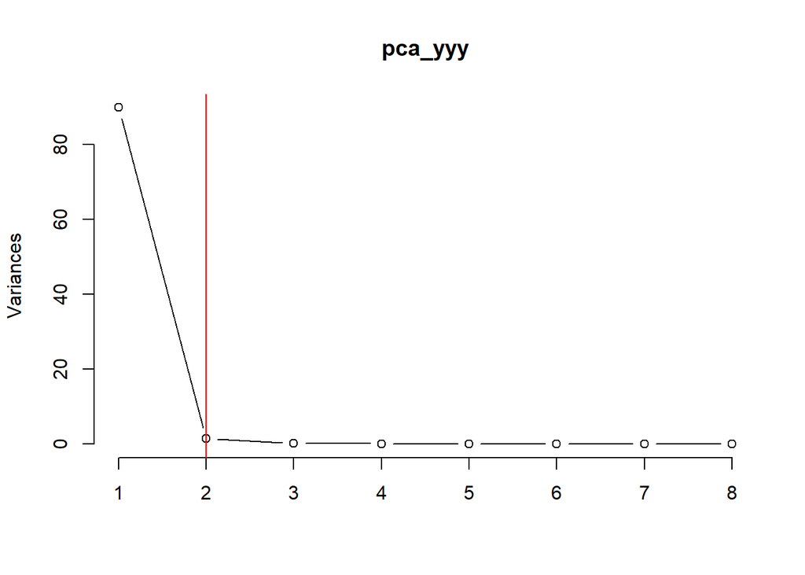

```r
screeplot(pca_yyy,npcs=8,type="lines")
abline(v=2,col='red')
```

##### **screeplot 이용하면 보면 PC1만 써야함**

### *따라서, 한 변수의 분산이 크면 좋지 않은 현상이 발견되는 차원축소를 하므로, 표준화를 하여 PCA를 적용하는 방법을 일반적으로 사용해야 한다.*